# Adaptive Management of Coypu via Stochastic Dynamic Programming

SIS metapopulation with local logistic dynamics, MDP value iteration, and forward simulation

Olivier Gimenez

25 February 2026

# 1 Overview

This document describes and motivates an adaptive management model for **coypu (ragondin)** control on a small spatial network of cities (sites). The ecological dynamics are modeled as a **binary SIS occupancy process** at the site level (Susceptible/empty vs. Infected/occupied), coupled with **local logistic population growth** when occupied. Management is framed as a **finite-action Markov Decision Process (MDP)** with a **global action** (same removal intensity at all sites every month). We:

1. Build a network of $n=8$ sites using an observed 2022 abundance vector $\mathbf{N}_{2022}$.
2. Specify local growth and harvest, plus stochastic **extinction** and **colonization**.
3. Estimate action-conditioned transition kernels $P_a$ by Monte Carlo.
4. Define **rewards** as (negative) **damage + control cost**.
5. Solve the MDP by **finite-horizon dynamic programming** (value iteration).
6. **Forward-simulate** abundance/occupancy under the optimal policy and compare with constant strategies.

# 2 Ecological–Management Model

## 2.1 Sites, states, and actions

We consider $n$ sites. At month $t$, site $i$ has binary occupancy
$$X_i(t)\in\{0,1\}\quad\text{with } X_i(t)=1 \text{ if occupied, else } 0.$$
The **global state** is the vector $\mathbf{X}(t) = (X_1(t),\dots,X_n(t))^\top \in \{0,1\}^n$. Let $\mathcal{S}=\{0,1\}^n$ and denote states by $s\in\mathcal{S}$.

At each month we choose a **global action** $a\in\mathcal{A}=\{0,1,2\}$ corresponding to **harvest intensities**
$$h_a \in \{0,\;0.1,\;0.2\} \quad\text{(none, moderate, strong)}.$$

The network is represented by an adjacency matrix $\mathbf{A}=(A_{ij})$, with $A_{ij}=1$ if sites $i$ and $j$ are neighbors. Let
$$k_i(t) = \sum_{j\neq i} A_{ij} X_j(t)$$
be the number of occupied neighbors of site $i$ at time $t$.

## 2.2 Local abundance dynamics with harvest

When a site is occupied $(X_i(t)=1)$, its abundance $N_i(t)$ follows **discrete logistic growth** with intrinsic rate $r$ and carrying capacity $K$, then experiences harvest (removal) with intensity $h_a$:
$$\underbrace{N_i^{\text{grow}}(t+1)}_{\text{growth}} \;=\; N_i(t) +
r\,N_i(t)\!\left(1-\frac{N_i(t)}{K}\right),\qquad
\underbrace{N_i(t+1)}_{\text{post-harvest}} \;=\;
N_i^{\text{grow}}(t+1)\,(1-h_a).$$
If $X_i(t)=0$, we set $N_i(t)=0$. We truncate at $N_i(t+1)\ge 0$ if needed.

## 2.3 Extinction and colonization

Conditional on the post-harvest abundance $N_i(t+1)$ and neighborhood occupancy $k_i(t)$, site $i$ updates its occupancy via: - **Extinction probability** (when currently occupied):
$$p_{\text{ext}}(N) \;=\; \exp(-\alpha N),\qquad \alpha>0.$$
Lower abundance increases extinction risk. - **Colonization probability** (when currently empty):
$$p_{\text{col}}(k) \;=\; 1 - (1-\beta)^{\,k},\qquad \beta\in(0,1).$$
More occupied neighbors increase colonization probability.

In the provided code, $\alpha=0.15$ and $\beta=0.1$.

## 2.4 State transitions under an action

Given a current state $s\in\mathcal{S}$ (i.e., $\mathbf{X}(t)=s$) and action $a$, the stochastic rules above induce a distribution over the next state $s'\in\mathcal{S}$. Closed-form transition probabilities are generally intractable because they depend on $\mathbf{N}(t)$, which itself depends on $s$, $a$, and parameters; therefore we **estimate** the transition matrix $P_a = \big[p_a(s,s')\big]$ **by Monte Carlo**:

1. Start from $s$, initialize $\mathbf{N}(t)$ using observed/assumed abundances for occupied sites and zeros otherwise.
2. Apply logistic growth and harvest with $h_a$.
3. For each site, draw extinction/colonization events using $p_{\text{ext}}$ or $p_{\text{col}}$, yielding a next state $s'$.
4. Repeat for many simulations (here $n_{\text{sims}}=100$) and set
   $$\hat p_a(s,s') \;=\;
   \frac{1}{n_{\text{sims}}}\sum_{m=1}^{n_{\text{sims}}}\mathbf{1}\{s'_m=s'\}.$$

# 3 Objective and Rewards

At any state $s$ with corresponding (post-growth, post-harvest) abundance vector $\mathbf{N}$, we define a **per-period cost**
$$C(s,a) \;=\; c_d \sum_{i=1}^n N_i \;+\; c_a(a),$$
where $c_d$ is the **damage cost per individual** (here $c_d=1$), and $c_a(a)$ is the **control cost** of action $a$ (here $c_a=\{0,5,10\}$ for none/moderate/strong). The **reward** is
$$R(s,a) \;=\; -\,C(s,a).$$

For discount factor $\gamma\in(0,1]$ and horizon $T$, the manager maximizes expected total discounted reward:
$$\max_{\pi}\;
\mathbb{E}_\pi\!\left[\;\sum_{t=0}^{T-1}\gamma^t\,R\big(S_t,
A_t\big)\;\right],$$
where $A_t=\pi_t(S_t)$ is a **Markov policy** (here a global action applied to all sites).

# 4 Dynamic Programming Solution

With transition matrices $\{P_a\}_{a\in\mathcal{A}}$ and reward matrix $R(\cdot,\cdot)$, the **finite-horizon** backward induction (value iteration) computes:
$$V_T(s)=0,\quad
V_t(s) \;=\; \max_{a\in\mathcal{A}} \Big\{ R(s,a) + \gamma
\sum_{s'\in\mathcal{S}} p_a(s,s')\,V_{t+1}(s') \Big\},\quad
t=T-1,\dots,0.$$
An **optimal policy** at time $t$ is any maximizer
$$\pi_t^\star(s)\in \arg\max_{a\in\mathcal{A}} \Big\{ R(s,a) + \gamma
\sum_{s'} p_a(s,s')\,V_{t+1}(s') \Big\}.$$

We implement this using the **`MDPtoolbox`** function `mdp_finite_horizon`, with $\gamma=0.99$ and $T=60$ months.

# 5 Code

```r
library(MDPtoolbox)
library(igraph)
library(tidyverse)
library(patchwork)
# Optional mapping & geocoding (internet required)
# library(leaflet)
# library(tidygeocoder)
set.seed(666)
```

## 5.1 Network, parameters, states

```r
# Sites and 2022 estimated abundances
villes  <- c("Candillargues","La Grande-Motte","Lansargues",
             "Marsillargues","Mauguio","Valergues",
             "Mudaison","Saint-Nazaire-de-Pézan")
pop_est <- c(80, 0, 125, 0, 50, 15, 0, 200)
n_sites <- length(villes)

# Random dense connected graph
g   <- sample_gnp(n_sites, p = 0.7)
while (!is_connected(g)) g <- sample_gnp(n_sites, p = 0.7)
adj <- as_adj(g, sparse = FALSE)
# Dynamics and management
K <- 250; r <- 0.7
actions       <- c(0, 0.1, 0.2)      # none / moderate / strong
control_cost  <- c(0, 5, 10)
damage_cost   <- 1
alpha <- 0.15 # extinction slope
beta  <- 0.1  # colonization per occupied neighbor
Tmax  <- 60
n_sims <- 100

# State space {0,1}^n
state_list <- as.matrix(expand.grid(replicate(n_sites, c(0,1), simplify=FALSE)))
n_states   <- nrow(state_list)
n_actions  <- length(actions)
```

## 5.2 Stochastic occupancy update

```r
simulate_next_state <- function(state, a_index, pop, adj) {
  next_state <- state
  for (i in seq_along(state)) {
    if (state[i] == 1) {
      p_ext <- exp(-alpha * pop[i])
      if (runif(1) < p_ext) { next_state[i] <- 0; pop[i] <- 0 }
    } else {
      nei   <- which(adj[i,] == 1)
      k     <- sum(state[nei])
      p_col <- 1 - (1 - beta)^k
      if (runif(1) < p_col) { next_state[i] <- 1; pop[i] <- 1 }
    }
  }
  list(state = next_state, pop = pop)
}
```

## 5.3 Monte Carlo transition matrices and rewards

```r
P <- vector("list", n_actions)
R <- matrix(0, n_states, n_actions)

for (a in seq_len(n_actions)) {
  P[[a]] <- matrix(0, n_states, n_states)
  for (s in seq_len(n_states)) {
    state <- state_list[s,]
    pop   <- ifelse(state == 1, pop_est, 0)

    # Local growth + harvest
    pop <- pop + r * pop * (1 - pop/K)
    pop <- pmax(0, pop * (1 - actions[a]))

    # Monte Carlo next-state sampling
    next_states <- matrix(0, nrow = n_sims, ncol = n_sites)
    for (m in 1:n_sims) {
      res <- simulate_next_state(state, a, pop, adj)
      next_states[m,] <- res$state
    }
    # tabulate
    idx <- apply(next_states, 1, function(row)
      which(apply(state_list, 1, function(x) all(x == row))))
    probs <- table(idx) / length(idx)
    P[[a]][s, as.integer(names(probs))] <- as.numeric(probs)

    # Reward = - (damage + control)
    R[s, a] <- - (damage_cost * sum(pop) + control_cost[a])
  }
}
```

## 5.4 Finite-horizon value iteration

```r
mdp_check(P, R)
```

```
## [1] ""
```

```r
disc    <- 0.99
res <- mdp_finite_horizon(P, R, discount = disc, N = Tmax)
res
```

[output not shown]

[output cut: 3846 more lines]

# 6 Forward Simulation under the Optimal Policy

Given an initial state from 2022 abundances, we **simulate forward**: 1. Read the optimal action for the current state from `res$policy`. 2. Apply growth + harvest and then stochastic extinction/colonization. 3. Record abundance and occupancy through time.

```r
pop_mat   <- matrix(NA, nrow = Tmax, ncol = n_sites)
state_mat <- matrix(NA, nrow = Tmax, ncol = n_sites)

pop   <- pop_est
state <- ifelse(pop > 0, 1, 0)
pop_mat[1,]   <- pop
state_mat[1,] <- state

for (t in 1:(Tmax-1)) {
  sid <- which(apply(state_list, 1, function(x) all(x == state)))
  a   <- res$policy[sid]

  pop <- ifelse(state == 1, pop + r * pop * (1 - pop/K), 0)
  pop <- pmax(0, pop * (1 - actions[a]))

  out   <- simulate_next_state(state, a, pop, adj)
  state <- out$state
  pop   <- out$pop

  pop_mat[t+1,]   <- pop
  state_mat[t+1,] <- state
}
```

# 7 Key Probability Functions

The model uses the following functional forms (as coded):

- **Extinction vs abundance**
  $$p_{\text{ext}}(N) = \exp(-\alpha N)\quad (\alpha=0.15)$$
- **Colonization vs occupied neighbors**
  $$p_{\text{col}}(k) = 1 - (1-\beta)^{k}\quad (\beta=0.1)$$

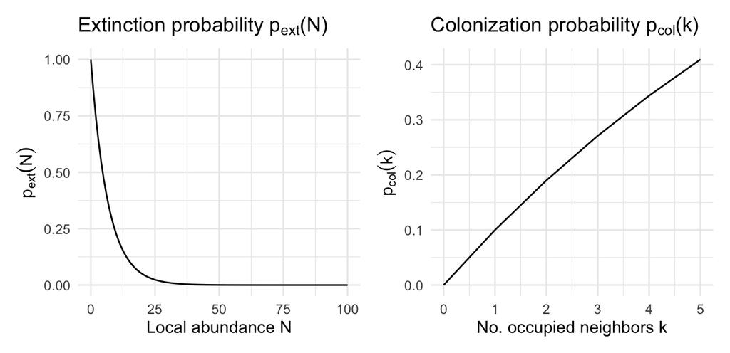

```r
df_ext <- tibble(N = 0:100, p_ext = exp(-0.15*N))
df_col <- tibble(k = 0:5,   p_col = 1 - (1 - 0.1)^k)
p1 <- ggplot(df_ext, aes(N, p_ext)) + geom_line() +
  labs(title = expression(paste("Extinction probability ", p[ext], "(N)")),
       x = "Local abundance N", y = expression(p[ext](N))) + theme_minimal()
p2 <- ggplot(df_col, aes(k, p_col)) + geom_line() +
  labs(title = expression(paste("Colonization probability ", p[col], "(k)")),
       x = "No. occupied neighbors k", y = expression(p[col](k))) + theme_minimal()
p1 + p2
```

# 8 Cumulative Costs: constant vs optimal strategies

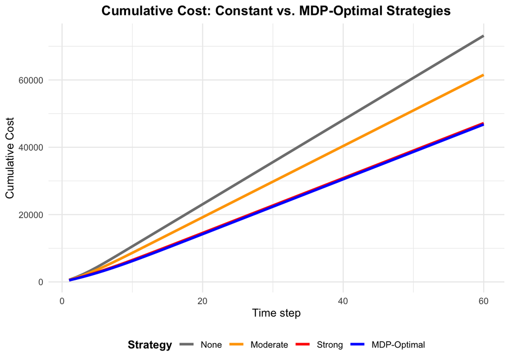

```r
# Initial conditions
state_init <- ifelse(pop_est > 0, 1, 0)
pop_init   <- pop_est

# Simulator for a constant action index a ∈ {1,2,3}
simulate_const <- function(a) {
  pop   <- pop_init
  state <- state_init
  cost  <- numeric(Tmax)
  for (t in 1:Tmax) {
    pop <- ifelse(state == 1, pop + r * pop * (1 - pop / K), 0)
    pop <- pmax(0, pop * (1 - actions[a]))
    cost[t] <- sum(pop) * damage_cost + control_cost[a]
    out     <- simulate_next_state(state, a, pop, adj)
    state   <- out$state
    pop     <- out$pop
  }
  cumsum(cost)
}

# Run for each constant strategy
cost_none     <- simulate_const(1)
cost_moderate <- simulate_const(2)
cost_strong   <- simulate_const(3)

# Calculate optimal actions & cost_step along the optimal trajectory
action_opt <- apply(state_mat, 1, function(st) {
  sid <- which(apply(state_list, 1, function(x) all(x == st)))
  res$policy[sid]
})
cost_step_opt <- purrr::map_dbl(seq_len(Tmax), function(t) {
  sum(pop_mat[t, ]) * damage_cost + control_cost[action_opt[t]]
})
cum_cost_opt  <- cumsum(cost_step_opt)

# Combine all into one data.frame
df_costs <- tibble(
  Time     = rep(1:Tmax, 4),
  CumCost  = c(cost_none, cost_moderate, cost_strong, cum_cost_opt),
  Strategy = factor(rep(c("None","Moderate","Strong","MDP-Optimal"), each = Tmax),
                    levels = c("None","Moderate","Strong","MDP-Optimal"))
)

ggplot(df_costs, aes(x = Time, y = CumCost, color = Strategy)) +
  geom_line(size = 1.2) +
  scale_color_manual(values = c("None"="grey50","Moderate"="orange",
                                "Strong"="red","MDP-Optimal"="blue")) +
  labs(title = "Cumulative Cost: Constant vs. MDP-Optimal Strategies",
       x = "Time step", y = "Cumulative Cost", color = "Strategy") +
  theme_minimal() +
  theme(plot.title = element_text(face = "bold", hjust = 0.5),
        legend.title = element_text(face = "bold"),
        legend.position = "bottom")
```

# 9 Abundance dynamics per site (optimal vs constant)

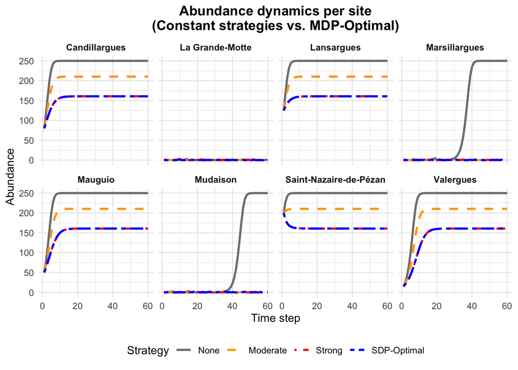

```r
mes_villes <- villes
pop_init_df <- tibble(Site = mes_villes, init = pop_est)

# Simulator that records pop × time for a single constant action a
simulate_mat <- function(a) {
  pop   <- pop_est
  state <- ifelse(pop_est > 0, 1, 0)
  M     <- matrix(0, nrow = Tmax, ncol = length(pop_est))
  for (t in 1:Tmax) {
    M[t, ] <- pop
    pop <- ifelse(state == 1, pop + r * pop * (1 - pop / K), 0)
    pop <- pmax(0, pop * (1 - actions[a]))
    out   <- simulate_next_state(state, a, pop, adj)
    state <- out$state
    pop   <- out$pop
  }
  M
}

mat_none     <- simulate_mat(1)
mat_moderate <- simulate_mat(2)
mat_strong   <- simulate_mat(3)
mat_opt      <- pop_mat   # from the optimal forward simulation

df_none <- as_tibble(mat_none) %>% set_names(mes_villes) %>%
  mutate(Time = 1:Tmax, Strategy = "None")
df_mod  <- as_tibble(mat_moderate) %>% set_names(mes_villes) %>%
  mutate(Time = 1:Tmax, Strategy = "Moderate")
df_str  <- as_tibble(mat_strong) %>% set_names(mes_villes) %>%
  mutate(Time = 1:Tmax, Strategy = "Strong")
df_opt  <- as_tibble(mat_opt) %>% set_names(mes_villes) %>%
  mutate(Time = 1:Tmax, Strategy = "SDP-Optimal")

df_all <- bind_rows(df_none, df_mod, df_str, df_opt) %>%
  pivot_longer(cols = all_of(mes_villes), names_to = "Site", values_to = "Abundance") %>%
  mutate(Strategy = factor(Strategy, levels = c("None","Moderate","Strong","SDP-Optimal")))

ggplot(df_all, aes(Time, Abundance, color = Strategy, linetype = Strategy)) +
  geom_line(size = 1) +
  facet_wrap(~ Site, ncol = 4) +
  scale_color_manual(values = c(None="grey50", Moderate="orange", Strong="red", `SDP-Optimal`="blue")) +
  scale_linetype_manual(values = c(None="solid", Moderate="dashed", Strong="dotdash", `SDP-Optimal`="twodash")) +
  labs(title = "Abundance dynamics per site\n(Constant strategies vs. MDP-Optimal)",
       x = "Time step", y = "Abundance", color = "Strategy") +
  theme_minimal() +
  theme(plot.title = element_text(face = "bold", hjust = 0.5),
        legend.position = "bottom",
        strip.text = element_text(face = "bold"))
```

# 10 Global optimal action sequence

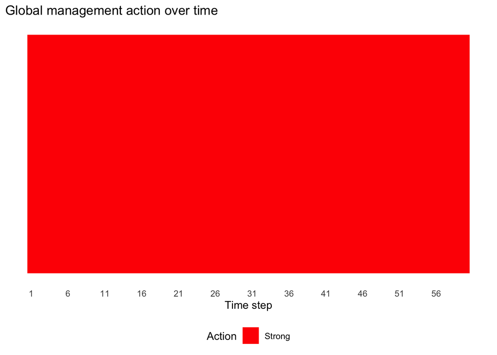

```r
action_opt <- apply(state_mat, 1, function(st) {
  sid <- which(apply(state_list, 1, function(x) all(x == st)))
  res$policy[sid]
})
action_seq <- tibble(Time = 1:Tmax,
                     Strategy = factor(action_opt, levels = 1:3,
                                       labels = c("None","Moderate","Strong")))

ggplot(action_seq, aes(x = Time, y = 1, fill = Strategy)) +
  geom_tile() +
  scale_fill_manual(name = "Action", values = c(None = "grey50", Moderate = "orange", Strong = "red")) +
  scale_y_continuous(NULL, breaks = NULL) +
  scale_x_continuous(breaks = seq(1, Tmax, by = 5)) +
  labs(title = "Global management action over time", x = "Time step") +
  theme_minimal() +
  theme(axis.title.y = element_blank(),
        panel.grid.major = element_blank(),
        panel.grid.minor = element_blank(),
        legend.position  = "bottom")
```

# 11 Heatmap of removals under the optimal policy

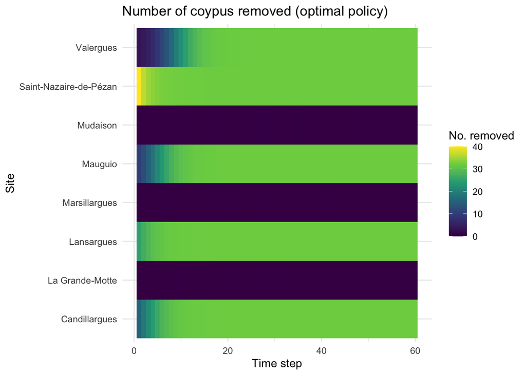

```r
harvest_mat <- pop_mat * actions[action_opt]
df_harvest <- as_tibble(harvest_mat) %>%
  set_names(mes_villes) %>%
  mutate(Time = 1:Tmax) %>%
  pivot_longer(cols = all_of(mes_villes), names_to = "Site", values_to = "Harvested")

ggplot(df_harvest, aes(x = Time, y = Site, fill = Harvested)) +
  geom_tile() +
  scale_fill_viridis_c(name = "No. removed") +
  labs(title = "Number of coypus removed (optimal policy)", x = "Time step", y = "Site") +
  theme_minimal()
```

# 12 Containment probability (≤ 5 indiv.)

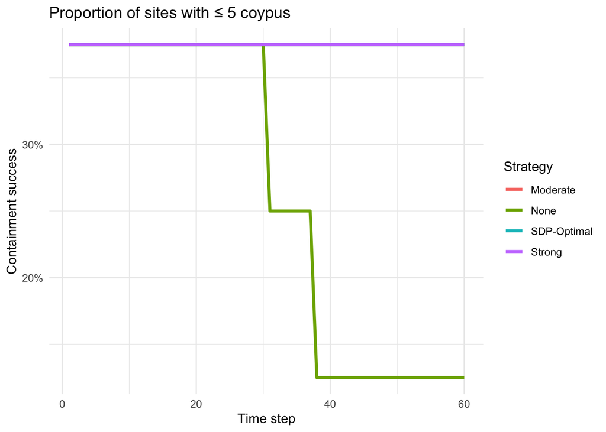

```r
df_all_for_summary <- bind_rows(df_none, df_mod, df_str, df_opt) %>%
  pivot_longer(cols = all_of(mes_villes), names_to = "Site", values_to = "Abundance")

df_summary <- df_all_for_summary %>%
  group_by(Time, Strategy) %>%
  summarise(perc_low = mean(Abundance <= 5), .groups = "drop")

ggplot(df_summary, aes(Time, perc_low, color = Strategy)) +
  geom_line(size = 1.2) +
  scale_y_continuous(labels = scales::percent) +
  labs(title = "Proportion of sites with ≤ 5 coypus",
       x = "Time step", y = "Containment success", color = "Strategy") +
  theme_minimal()
```

# 13 (Optional) Map of study area (internet required)

```r
library(leaflet)
library(tidygeocoder)

mes_villes <- c("Candillargues", "La Grande-Motte", "Lansargues",
                "Marsillargues", "Mauguio", "Valergues",
                "Mudaison", "Saint-Nazaire-de-Pézan")
effectifs <- c(80, 0, 125, 0, 50, 15, 0, 200)

cities_df <- tibble(ville = mes_villes) %>%
  geocode(address = ville, method = "osm", lat = latitude, long = longitude, full_results = FALSE) %>%
  mutate(ragondins = effectifs)

leaflet(cities_df) %>%
  addProviderTiles(providers$OpenStreetMap, group = "Plan") %>%
  addProviderTiles(providers$Esri.WorldImagery, group = "Satellite") %>%
  addCircleMarkers(lng = ~longitude, lat = ~latitude,
                   popup = ~paste0("<strong>", ville, "</strong><br/>","Ragondins : ", ragondins),
                   radius = ~5 + sqrt(ragondins), fillOpacity = 0.3, color = "red",
                   group = "Communes", label = ~as.character(ragondins),
                   labelOptions = labelOptions(noHide = TRUE, direction = "top", textOnly = TRUE)) %>%
  addLayersControl(baseGroups = c("Plan","Satellite"), overlayGroups = "Communes",
                   options = layersControlOptions(collapsed = FALSE)) %>%
  addLegend(position = "bottomright", colors = "red", labels = "Commune", title = "Points villes") %>%
  addControl(html = "<strong>Carte Plan – Effectifs de ragondins</strong>", position = "topright")
```

# 14 Interpretation and Extensions

- The **global action** constraint makes the policy **coarse-grained**: every month, the same removal intensity is applied to all sites.
- Using **Monte Carlo** to build $P_a$ propagates nonlinearity from logistic-growth and the extinction/colonization rules into the decision problem.
- The **reward structure** balances **damage** (proportional to abundance) against **control costs**, allowing trade-off exploration by changing $c_d$, $c_a$, $r$, $K$.
- A **finite horizon** ($T=60$ months) with $\gamma\approx 1$ approximates a long-term objective while allowing time-dependent policies $\pi_t^\star$.
- Because colonization couples sites through the graph $\mathbf{A}$, **network structure** critically shapes optimal strategies.

**Extensions:** sensitivity to $\alpha,\beta,r,K,c_d,c_a$; site-specific or budget-constrained actions; POMDPs for partial observation; Bayesian adaptive learning over parameters.